# Actividad1.8

Cesar Vazquez

2022-11-15

```r
library(psych)
library(polycor)
```

```r
library(ggcorrplot)
library(GPArotation)
library(performance)
```

```r
M = read.csv("datoslago.csv")
M
```

```
##    Tamano Temperatura Proteinas Oxigeno LnProteinas  LnTamano
## 1     7.5        13.8      65.9     2.8   4.1881384 2.0149030
## 2     5.8        13.8      20.3     2.8   3.0106209 1.7578579
## 3     8.0        13.8     136.6     2.8   4.9170569 2.0794415
## 4     8.0        13.8      70.5     2.8   4.2556127 2.0794415
## 5    10.0        13.8     117.8     2.8   4.7689883 2.3025851
## 6    10.4        13.8     119.7     2.8   4.7849886 2.3418058
## 7     7.5        13.8      68.2     2.8   4.2224446 2.0149030
## 8    10.2        13.8      98.0     2.8   4.5849675 2.3223877
## 9     9.5        13.8      78.9     2.8   4.3681812 2.2512918
## 10    4.6        13.8      18.7     2.8   2.9285235 1.5260563
## 11    9.0        13.8      86.8     2.8   4.4636066 2.1972246
## 12    9.8        13.8      82.0     2.8   4.4067192 2.2823824
## 13   11.0        13.8     184.4     2.8   5.2171073 2.3978953
## 14   11.2        13.8     113.7     2.8   4.7335634 2.4159138
```

[output cut: 76 more lines]

1. Obtener la matriz de correlaciones y la matriz de valores p de significancia por pares. Interpreten los resultado en equipo.

```r
corr.test(M)  # M es la matriz de datos
```

```
## Call:corr.test(x = M)
## Correlation matrix
##             Tamano Temperatura Proteinas Oxigeno LnProteinas LnTamano
## Tamano        1.00        0.23      0.63   -0.34        0.84     0.97
## Temperatura   0.23        1.00     -0.22    0.34       -0.08     0.22
## Proteinas     0.63       -0.22      1.00   -0.37        0.78     0.57
## Oxigeno      -0.34        0.34     -0.37    1.00       -0.38    -0.31
## LnProteinas   0.84       -0.08      0.78   -0.38        1.00     0.86
## LnTamano      0.97        0.22      0.57   -0.31        0.86     1.00
## Sample Size
## [1] 90
## Probability values (Entries above the diagonal are adjusted for multiple tests.)
##             Tamano Temperatura Proteinas Oxigeno LnProteinas LnTamano
## Tamano        0.00        0.12      0.00    0.01        0.00     0.00
## Temperatura   0.03        0.00      0.12    0.01        0.46     0.12
## Proteinas     0.00        0.04      0.00    0.00        0.00     0.00
## Oxigeno       0.00        0.00      0.00    0.00        0.00     0.02
## LnProteinas   0.00        0.46      0.00    0.00        0.00     0.00
## LnTamano      0.00        0.04      0.00    0.00        0.00     0.00
##
##  To see confidence intervals of the correlations, print with the short=FALSE option
```

Apartir de los p-values del test de correlacióm, observamos que existen algunos pares con p-values < 0.05, el cual es el nivel de significancia.

2. Hacer una gráfica de la matriz de correlaciones. Hacer un comentario entre todos los del equipo de la gráfica.

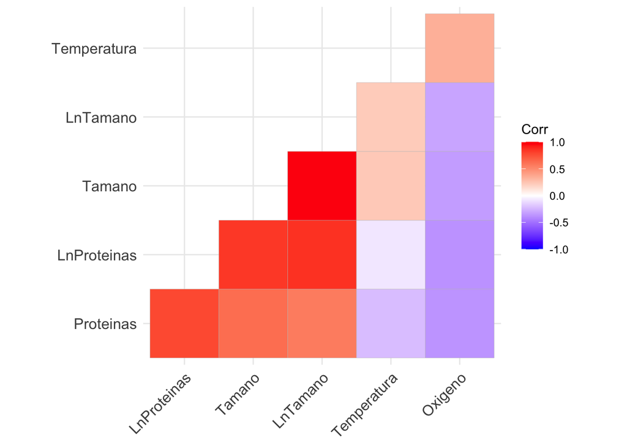

```r
mat_cor <- hetcor(M)$correlations #matriz de correlación policórica
ggcorrplot(mat_cor,type="lower",hc.order = T)
```

3. Aplicar una prueba de correlación conjunta a los datos para verficar si es aplicable el Análisis Factorial y concluir.

```r
check_sphericity_bartlett(M)
```

```
## # Test of Sphericity
##
## Bartlett's test of sphericity suggests that there is sufficient significant correlation in the data for factor analysis (Chisq(15) = 557.86, p < .001).
```

La prueba de Barlett analiza la similitud de varianzas, obtenemos un p-value < 0.001, el cual nos asegura que hay suficiente correlación para realizar un análisis factorial.

4. Otra prueba para, para comprobar si el análisis factorial es viable, y muy citada, es la prueba KMO. Aplíquela a estos datos, ¿contradice los resutados del inciso anterior?

```r
R = cor(M)
K = KMO(R)
cat("El valor del estadístico es: ", K$MSA)
```

```
## El valor del estadístico es:  0.6297281
```

5. Si los datos pasaron la prueba de los puntos anteriores 3 y 4, hacer un análisis factorial usando el criterio de máxima verosimilitud y el de mínimo residuo

```r
R = cor(M)
modelo1 = fa(R, nfactors =2, rotate = "none", fm = "mle")   # de máxima verosimilitud
modelo2 = fa(R, nfactors = 2, rotate = "none", fm = "minres") # Modelo de mínimo residuo
M1_commd = sort(modelo1$communality,decreasing = T)
M2_commd= sort(modelo2$communality,decreasing = T)
cbind(M1_commd,M2_commd)
```

```
##              M1_commd  M2_commd
## LnTamano    0.9950455 0.9748176
## Tamano      0.9558283 0.9238582
## LnProteinas 0.9181230 0.9030553
## Proteinas   0.7708383 0.8453996
## Temperatura 0.3963254 0.6029645
## Oxigeno     0.2071029 0.2835476
```

Esta dentro del rango de “mediocre”, entre 0.6 y 0.69. Esto no contradice perse los resultados anteriores, si bien es mediocre el análisis es viable, pero las condiciones no son las ideales.

6. Determine el número de factores adecuado según el criterio del gráfico de Cattell

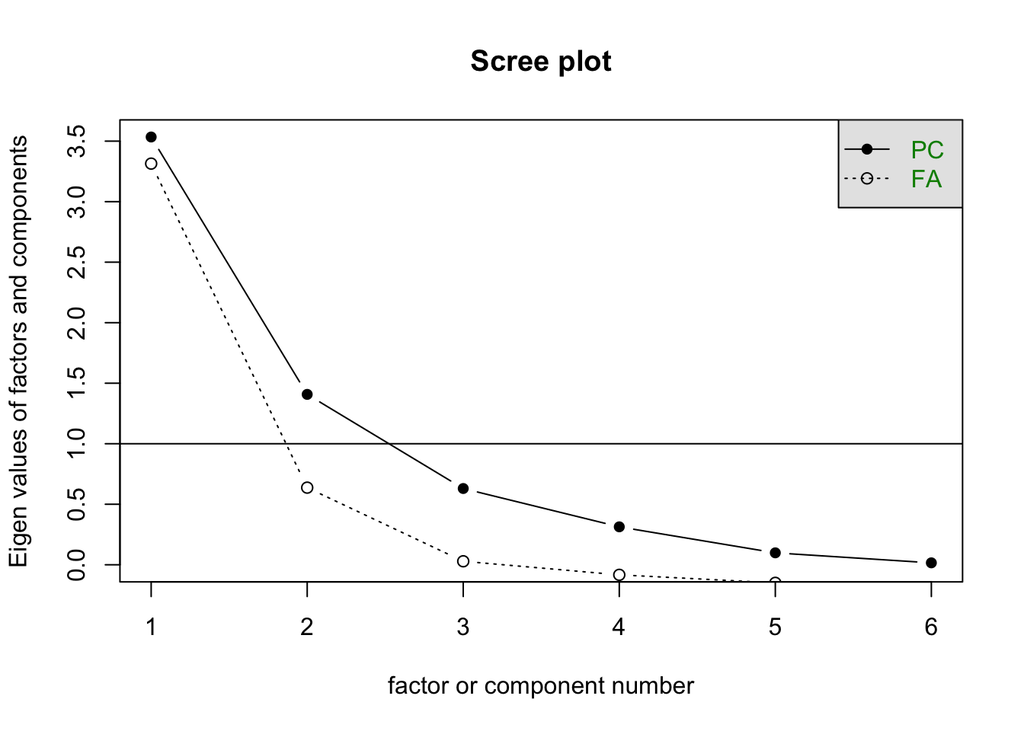

```r
R = cor(M)
scree(R) # se grafican los valores propios de R, y del análisis Factorial
```

La variable oxigeno es la menos explicada, ya que el modelo solo puede reproducir el 28.35% (criterio de mínimo residuo) y el 20.71% (criterio de máxima verosimilitud), y la que es mayor explicada por el modelo es LnTamaño con 97.48% (criterio de mínimo residuo) y el 99.50% (criterio de máxima verosimilitud).

7. Realicen los gráficos correspondientes a la rotación Varimax y quartimax de los datos e interpreten en equipo los resultados.

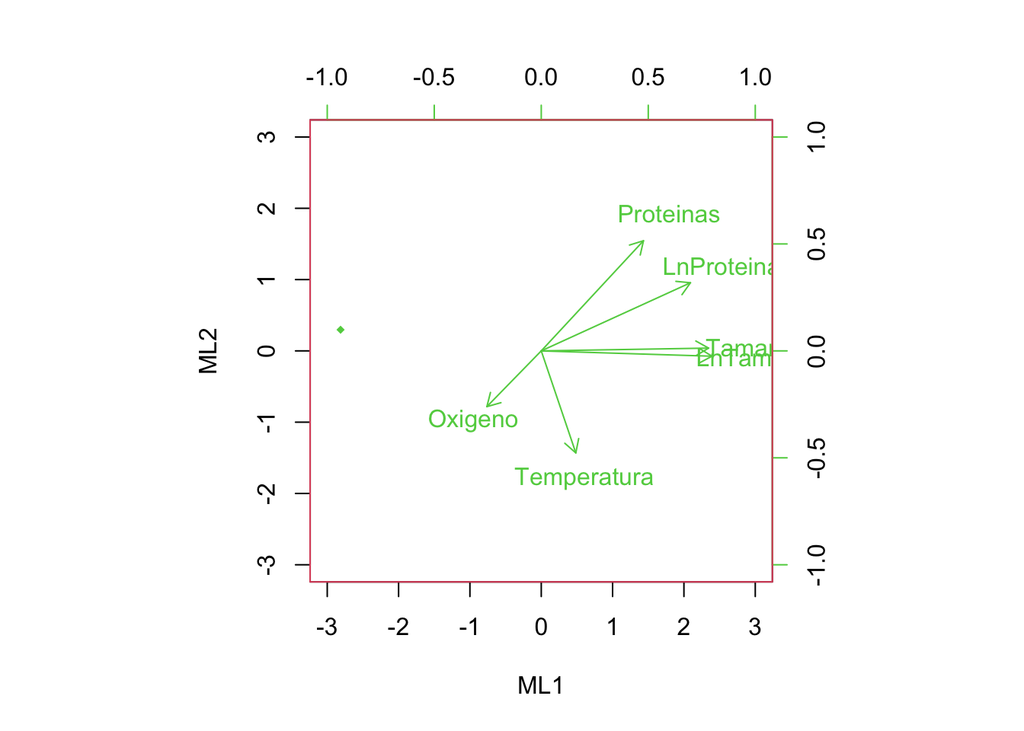

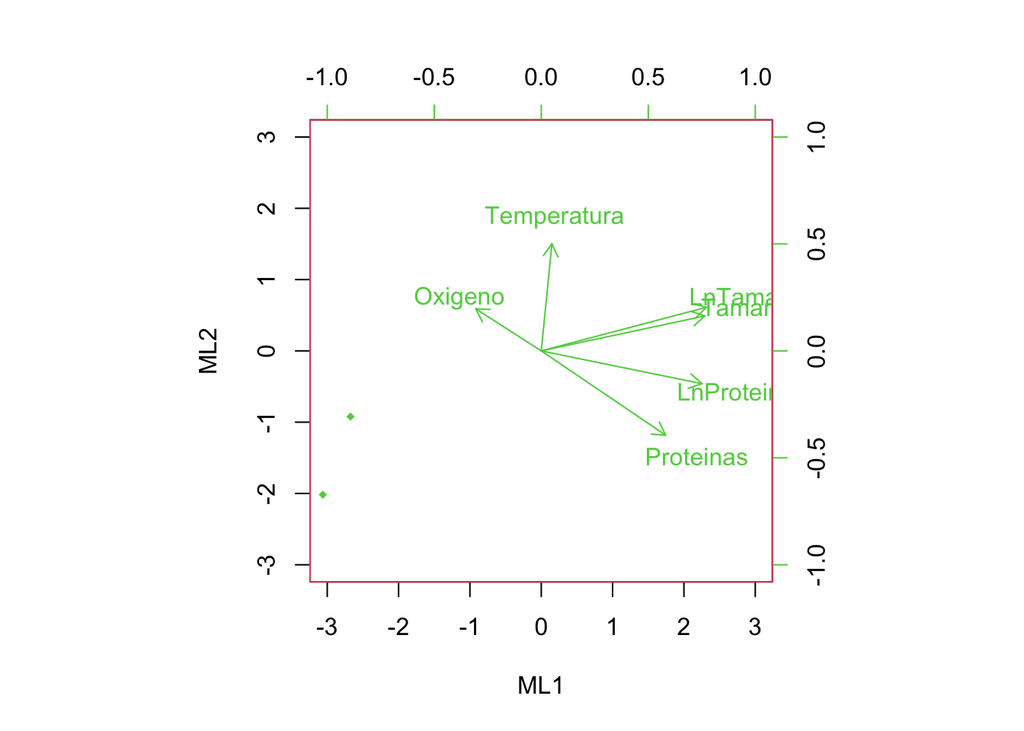

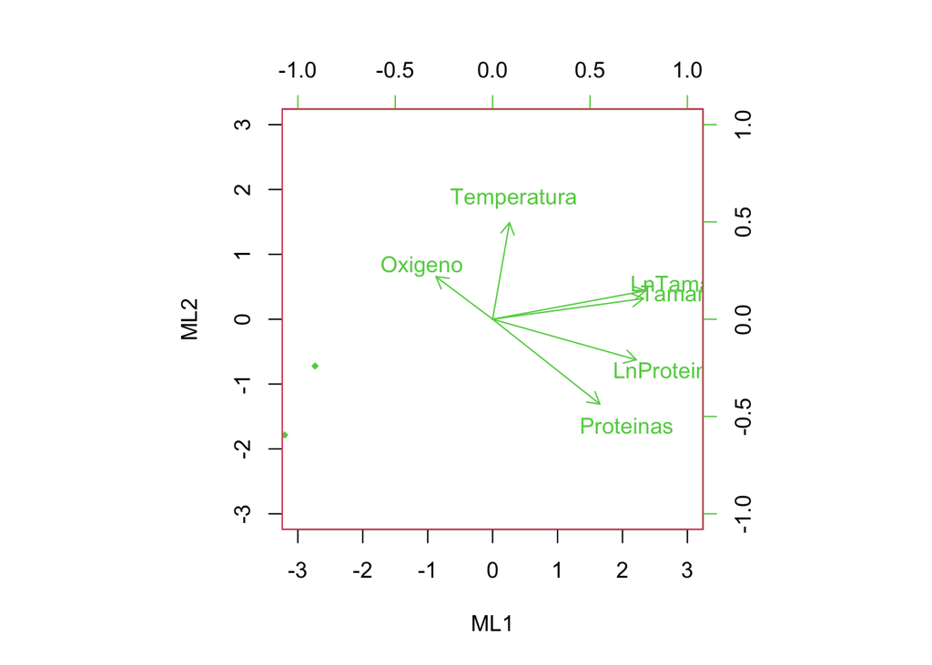

```r
R = cor(M)
rot = c("none", "varimax", "quartimax")
bi_mod = function(tipo){
biplot.psych(fa(M,nfactors = 2,fm="mle",rotate = tipo),main = "",col=c(2,3,4),pch = c(21,18),group = M[,"Tamano"])
}
sapply(rot,bi_mod)
```

8. ¿Qué pueden concluir? ¿Resultó razonable para este caso el modelo de análisis factorial? Expliquen.

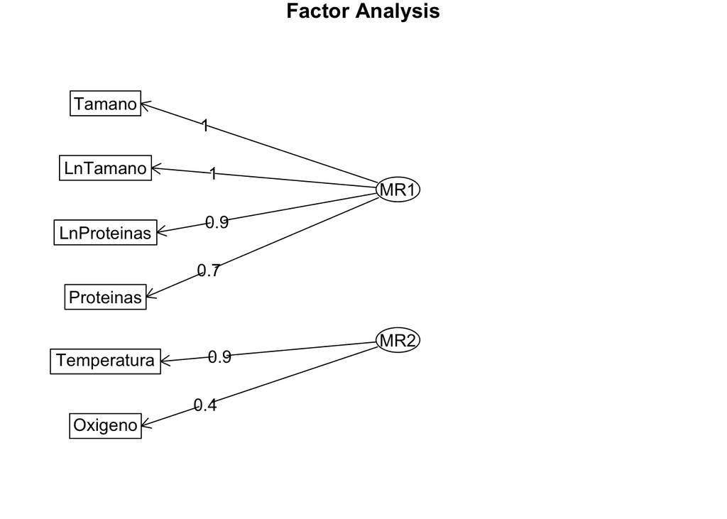

```r
modelo_varimax = fa(R,nfactors = 2,rotate = "varimax", fa="minres")
fa.diagram(modelo_varimax)
```

Igual que en el anterior la rotación ayuda en la interpretación de los resultados de agrupación: existen 2 grupos uno relacionado con Tamaño, LnTamaño, LnProteinas y Proteinas, y el otro de Temperatura y Oxígenos. Esto podria verse relacionado debido a que el ultimo grupo depende más de condiciones climaticas. Por lo tanto parece viable realizar un análisis.